# Solutions to regression book by Sheather, chapter 4

Arshak Parsa

2025-01-09

## Problem 1

Use `scan()` and `dput()` to read data!

```r
xp = c(0, 2, 4, 6, 8, 12, 17, 22, 28, 34)
size = c(17, 33, 19, 25, 18, 60, 58, 31, 34, 19)
salary = c(101300, 111303, 98000, 124000, 128475, 117410, 115825, 134300,128066, 164700)
```

Let’s have a vision

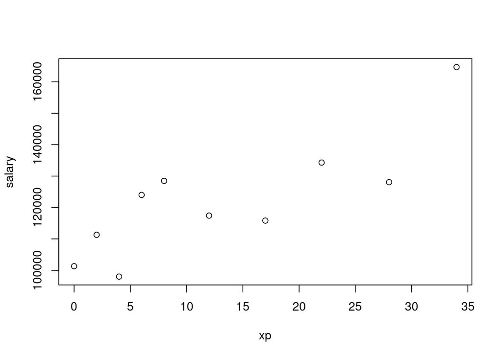

```r
plot(xp,salary)
```

Try a simple model

```r
m = lm(salary~xp)
summary(m)
```

```
##
## Call:
## lm(formula = salary ~ xp)
##
## Residuals:
##    Min     1Q Median     3Q    Max
## -14150  -9430  -1428   9712  14370
##
## Coefficients:
##             Estimate Std. Error t value Pr(>|t|)
## (Intercept) 104352.9     5619.4  18.570 7.29e-08 ***
## xp            1352.3      325.7   4.152   0.0032 **
## ---
## Signif. codes:  0 '***' 0.001 '**' 0.01 '*' 0.05 '.' 0.1 ' ' 1
##
## Residual standard error: 11320 on 8 degrees of freedom
## Multiple R-squared:  0.683,  Adjusted R-squared:  0.6434
## F-statistic: 17.24 on 1 and 8 DF,  p-value: 0.0032
```

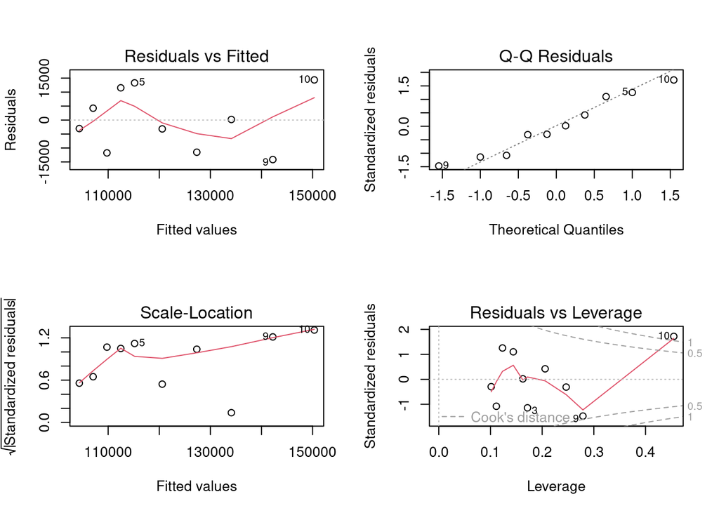

```r
par(mfrow=c(2,2))
plot(m)
```

```r
print("OLS Estimation :")
```

[1] “OLS Estimation :”

```r
predict(m,data.frame(xp=c(6)))
```

```
   1
```

112466.4

```r
print("Error :")
```

[1] “Error :”

```r
salary[4]-predict(m,data.frame(xp=c(6)))
```

```
   1
```

11533.56

Now, let’s make a use of sample sizes

```r
mw = lm(salary~xp,weights = size)
summary(mw)
```

```
##
## Call:
## lm(formula = salary ~ xp, weights = size)
##
## Weighted Residuals:
##    Min     1Q Median     3Q    Max
## -67520 -40994   4937  51648  87516
##
## Coefficients:
##             Estimate Std. Error t value Pr(>|t|)
## (Intercept) 104759.0     5752.2   18.21 8.49e-08 ***
## xp            1172.5      336.9    3.48  0.00832 **
## ---
## Signif. codes:  0 '***' 0.001 '**' 0.01 '*' 0.05 '.' 0.1 ' ' 1
##
## Residual standard error: 57620 on 8 degrees of freedom
## Multiple R-squared:  0.6022, Adjusted R-squared:  0.5524
## F-statistic: 12.11 on 1 and 8 DF,  p-value: 0.008323
```

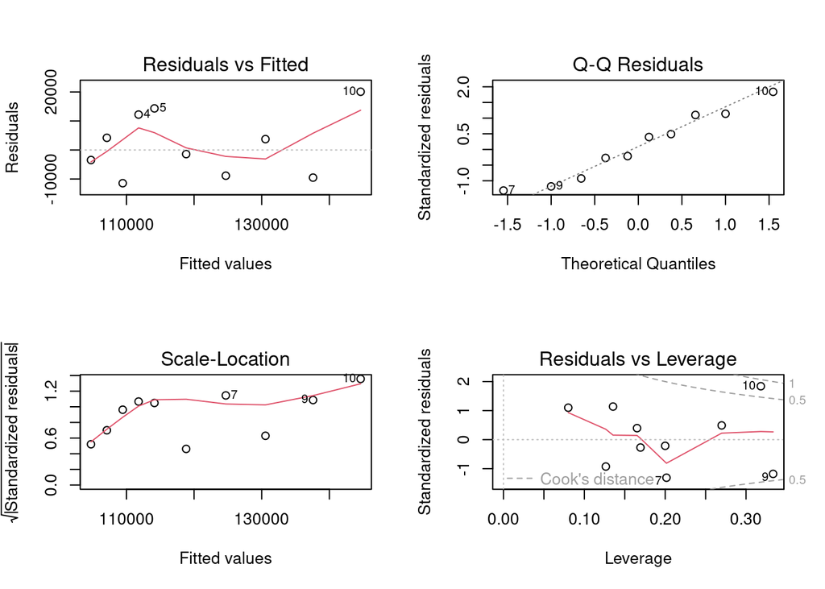

```r
par(mfrow=c(2,2))
plot(mw)
```

The outputs don’t look good, I prefer not to use WLS in this situation!

```r
print("WLS Estimation :")
```

```
## [1] "WLS Estimation :"
```

```r
predict(mw,data.frame(xp=c(6)))
```

```
##        1
## 111793.8
```

```r
print("Error :")
```

```
## [1] "Error :"
```

```r
salary[4]-predict(mw,data.frame(xp=c(6)))
```

```
##        1
## 12206.21
```

Let’s do it with bare hands!

```r
xwm = sum(size*xp)/sum(size)
ywm = sum(size*salary)/sum(size)
sxw = sum(size*(xp-xwm)^2)
sxyw = sum(size*(xp-xwm)*(salary-ywm))
b1 = sxyw/sxw
c(ywm - xwm*b1,b1)
```

```
## [1] 104759.048   1172.456
```

Fun fact: If you use the inverse of the sizes as your weights, you get a better model!

```r
mw = lm(salary~xp,weights = 1/size)
summary(mw)
```

```
##
## Call:
## lm(formula = salary ~ xp, weights = 1/size)
##
## Weighted Residuals:
##     Min      1Q  Median      3Q     Max
## -3148.9 -1528.5  -576.5  1766.0  2924.2
##
## Coefficients:
##             Estimate Std. Error t value Pr(>|t|)
## (Intercept) 103925.6     5232.1  19.863  4.3e-08 ***
## xp            1517.9      305.8   4.964   0.0011 **
## ---
## Signif. codes:  0 '***' 0.001 '**' 0.01 '*' 0.05 '.' 0.1 ' ' 1
##
## Residual standard error: 2243 on 8 degrees of freedom
## Multiple R-squared:  0.7549, Adjusted R-squared:  0.7242
## F-statistic: 24.64 on 1 and 8 DF,  p-value: 0.001102
```

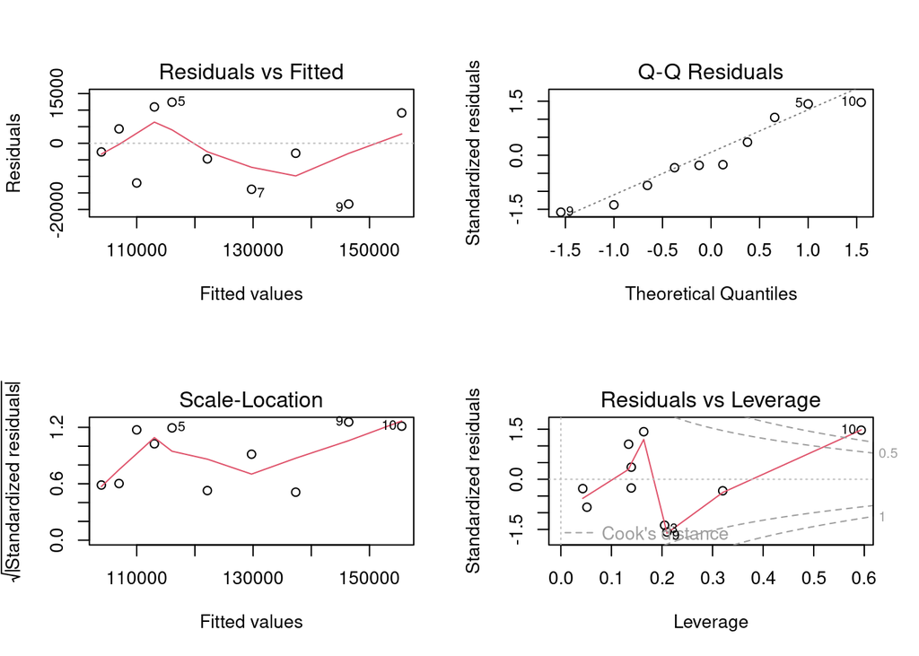

```r
par(mfrow=c(2,2))
plot(mw)
```

```r
print("Weird WLS Estimation :")
```

```
## [1] "Weird WLS Estimation :"
```

```r
predict(mw,data.frame(xp=c(6)))
```

```
##      1
## 113033
```

```r
print("Error :")
```

```
## [1] "Error :"
```

```r
salary[4]-predict(mw,data.frame(xp=c(6)))
```

```
##     1
## 10967
```

I suspect that the problem is related to $Y_i$ since it’s neither average nor median; it’s a **third quantile**, so $n_i=w_i$ is not appropriate! Anyways, I don’t like this WLS method at all!

## Problem 2

Easy! Let’s assume $Var(e_i)=\sigma^2/w_i$

We multiply the model equation by $\sqrt{w_i}$

$$\sqrt{w_i}y_i = \sqrt{w_i}\hat{\beta}x_i
+ \sqrt{w_i}e_i \quad where \quad \sqrt{w_i}e_i \sim N(0,\sigma^2)$$

$$SSE = \sum_{i=1}^n \hat{e_i}^2 =
\sum_{i=1}^n (\sqrt{w_i}y_i - \hat{y_i})^2 = \sum_{i=1}^n (\sqrt{w_i}y_i
- \sqrt{w_i}\hat{\beta}x_i)^2$$

$$\frac{dSSE}{d\hat{\beta}} = \sum_{i=1}^n
-2x_iw_i(y_i - \hat{\beta}x_i) = 0$$

$$\rightarrow \sum_{i=1}^n x_iw_i(y_i -
\hat{\beta}x_i) = 0 \rightarrow \hat{\beta} = \frac{\sum_{i=1}^n
x_iy_iw_i}{\sum_{i=1}^n x_i^2w_i}$$

Now, since $Var(e_i|x_i)=x_i^2\sigma^2=\sigma^2/w_i$ implies $w_i=x_i^{-2}$, we get $\hat{\beta} = \frac{\sum_{i=1}^n x_i^{-1}y_i}{n}$

## Problem 3

### a

According to the last subsection of this chapter (4.1.5), when $Y_i$ is the average or the **median** of $n_i$ observations, we shall use $n_i$ as model weights. Since $Y_i$ is “2006 **median** price per square foot”, it’s reasonable to choose $n_i$ as model weights.

### c

Try out the approach 1 or 2! It’s the only magic left!

One thing to note: the distribution of `x1i` and `x2i` are **highly skewed**. Sounds familiar? A transformation may definitely help!